# Revision of studies by other composers

**88** correction of Chekhover 1954 (=3010.20a7f5) U2. **1. Bf7!** (1. Be6? Qc3+) ( 1. Bh7? Qc3+) (1. a7? Qa6) **1… Qc3+ 2. Kb7 Qxg7** (2… Qb2+ **main** 3. Kc8! (3. Kc7? Qxg7 4. a7 Qe5+) 3… Qxg7 4. a7 Qf8+ (4… Qc3+ **main** 5. Bc4! (5. Kb7? Qb4+) 5… Qa5 eg 6. Kb7) (4… Qg2 **main** 5. Bd5! ( 5. Kb8? Qb2+ 6. Bb3 Qe5+) 5… Qxd5 6. Kb8) 5. Be8! (5. Kb7? Qb4+) 5… Qc5+ eg 6. Kb7) **3. a7 Qb2+ 4. Bb3! Qg7+ 5. Bf7!** (5. Kb6? Qd4+ 6. Ka6 (6. Kb7 Qb4+ 7. Kc7 Qc5+ 8. Kb7 Qb5+ 9. Kc7 Qa6 10. Kb8 Qb6+) 6… Qe4 Note that with the bK on f5, 7. Bc2 would draw here! ) **5… Qb2+ 6. Bb3 Qg7+ 7. Bf7 Qg2+ 8. Bd5! 1/2-1/2**.

**89** correction of Herbstman 1925 (=0403.11g4g8) U2. **1. a8=Q+ Rxa8 2. Kf5 Kg7 3. Rg4+ Kf7 4. Ra4 Rxa4 1/2-1/2**.

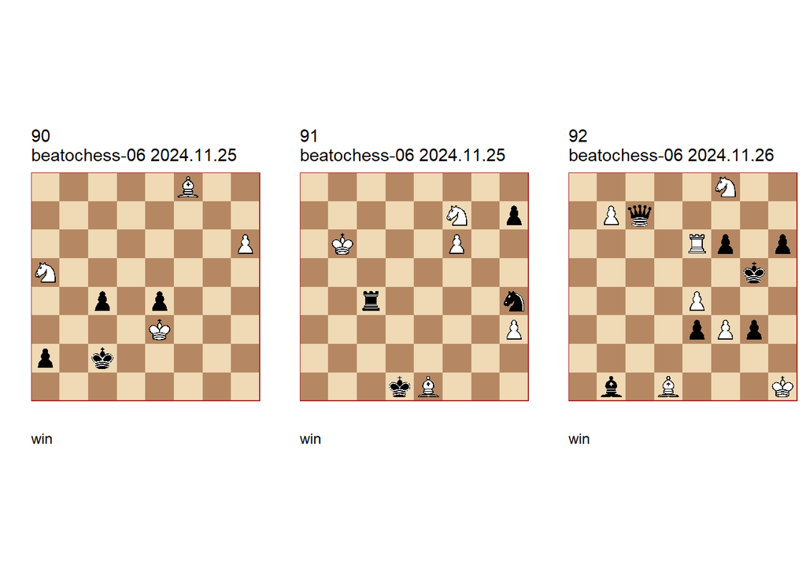

**90** correction Levman 1925 (+0011.12e2c2) U2. **1. Bg7 c3 2. Nb3!** (2. Bxc3? Kxc3 3. h7 a1=Q 4. h8=Q+ Kc2 5. Qxa1 (5. Qh2+ Kb1) ) **2… Kxb3 3. Bxc3 Kxc3 4. h7 a1=Q 5. h8=Q+ 1-0**.

**91** correction of Levman 1925 (+0314.21b7d1) U1. **1. Ne5 Rf4 2. Bxh4 Rxh4 3. Ng4 Rh5 4. f7 Rf5 5. Ne3+ 1-0**.

**92** correction of Lerner 1925 (+3141.34h1g5) U3. **1. Re5+** (1. Rc6? e2! -+) **1… Qxe5 2. f4+ Kxf4** (2… Qxf4 **main** 3. Ne6+ Kh4 4. Nxf4 Bxe4+ 5. Ng2+) **3. Ng6+ Kg5 4. Nxe5 Bxe4+ 5. Nf3+ 1-0**.

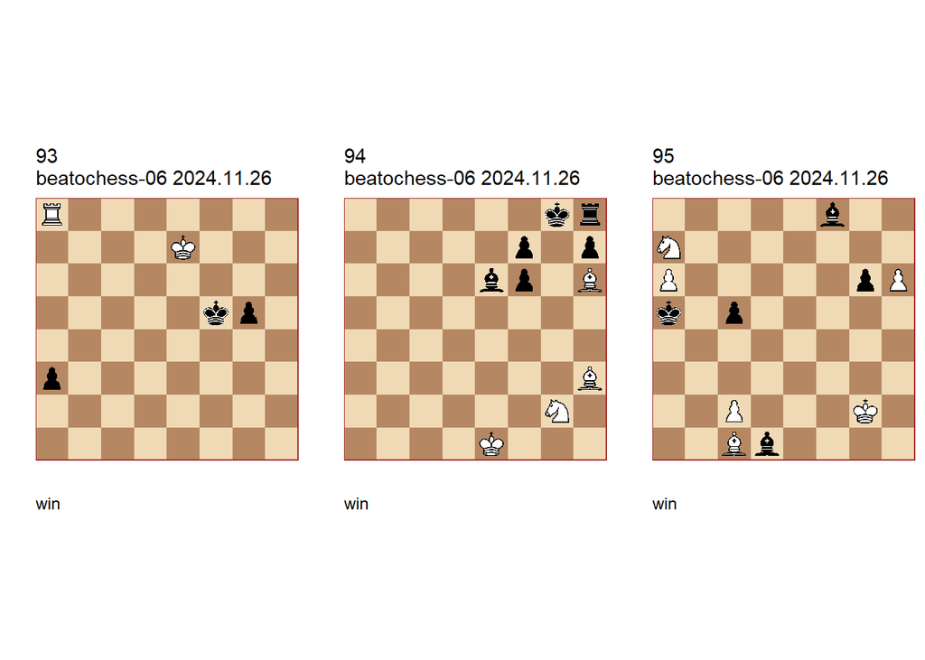

**93** correction of Tarrasch 1925(+0100.02e7f5) U1 U2. **1. Kd6 g4** (1… Ke4 2. Ra4+) **2. Kd5 Kf4 3. Kd4 g3 4. Rf8+ Kg4 5. Ke3** (5. Ke4 or ) (5. Rf1? g2 6. Ra1 Kf3) **1-0**.

**94** correction of Voinov 1925 (+0351.25h2g8) U2 U1. **1. Bf5!** (1. Nf4? f5 2. Bf1 Ba2! (2… Bb3? 3. Kd2 f6 4. Kc3 Ba2 5. Kb2) 3. Kd2 f6) **1… Bxf5 2. Nf4 Be6** (2… Bg6 **main** 3. Nd5) **3. Nh5 1-0**.

**95** correction of Zalkind 1925 (+0071.32g2a5) U1 U2. **1. h7 Bg7 2. Bb2 Bxb2 3. c3 Bxc3 4. Nb5 Kxb5 5. a7 1-0**.

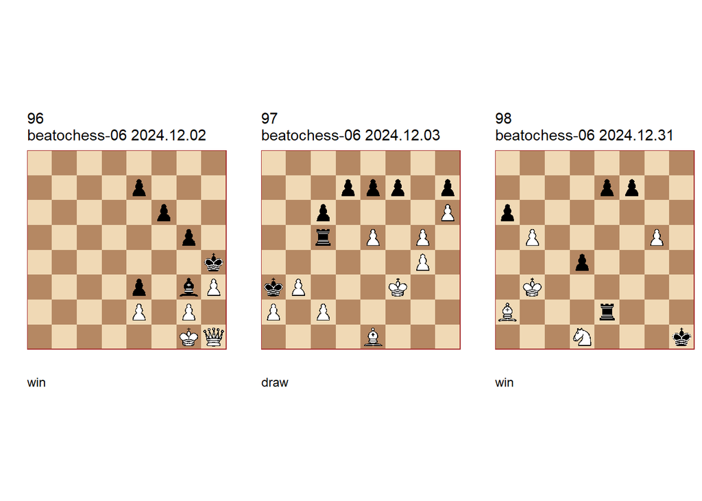

**96** correction of Bondarenko/Kuznetsov 1974 (+1030.44g1h4) U2. **1. Kf1 f5 2. Qg1 f4 3. Qh1 Kh5 4. h4 g4 5. Qg1 Bf2 6. Qh2 Bg3 7. Qh1 e6 8. Qg1 Bf2 9. Qh2 Bg3 10. Qh1 e5 11. Qg1 Bf2 12. Qh2 Bg3 13. Qh1 e4 14. Qg1 Bf2 15. Qh2 Bg3 16. Qh1 Kg6 17. h5+ Kh6 18. Qg1 Bf2 19. Qh2 Bg3 20. Qh1 Kg7 21. h6+ Kh7 22. Qh5 1-0**.

**97** version of Bondarenko/Kuznetsov 1974 (=0312.55f3a1) U2. **1. e6! dxe6 2. g6! fxg6 3. c4! Kxa2 4. Bb4 Rg5 5. Bd2 Re5 6. Bc3 Rc5 7. Bb4 Re5 8. Bc3 Rg5 9. Bd2 1/2-1/2**.

**98** correction of Troitzky 1923 (+0311.24b3h1) U1 U2. **1. b6!** (1. bxa6? Re6 2. Kc2 Rxa6 3. Bxf7 Ra3 4. g6 Rg3 5. Nf2+ Kg2 6. Ne4 Rg4 7. Kd3 Kf3 8. Nc5 e5) ( 1. g6 fxg6 2. b6 Re6 3. b7 Rb6+ 4. Ka3 g5) **1… Re6! 2. b7 Rb6+ 3. Ka3 e6 4. Bb1! Rxb1 5. Nb2 Ra1+ 6. Kb4** (6. Kb3? Ra5 7. b8=Q Rb5+ 8. Qxb5 axb5 9. Nd3 Kg2 10. Ne5 d3 11. Kc3 (11. Nxd3 Kf3 12. Ne5+ Ke4 13. Nxf7 Kf5) 11… Kg3 12. Nxf7 Kf4 13. g6 Ke3) **6… Rb1 7. Kb3 1-0**.

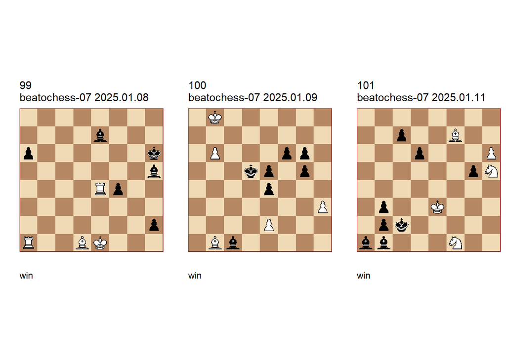

**99** correction of Fritz 1973 (+0243.03e1h6) U1. **1. Re6+** (1. Rxa6+? Bf6 2. Rxf6+ Kg7 3. Rf7+ Bxf7 (3… Kg8 4. Re8+) 4. Bf3 Bd5) **1… Bf6** (1… Kg7 2. Rxe7+ Kf8 3. Re8+ Kg7 4. Rg8+ Kf6 5. Rxa6+ Ke7 6. Rg7+ Kf8 7. Rf7+) **2. Rxf6+ Kg7 3. Rg6+ Kf8** (3… Kh7 4. Bc2) **4. Rg8+ Ke7 5. Re8+ Kd6 6. Re6+** (6. Rxa6+? Kc7) **6… Kc7 7. Rc6+ Kd7 8. Bf3 Bxf3 9. Rh6 h1=Q+ 10. Rxh1 Bxh1 11. O-O-O+ 1-0**.

**100** correction of Troitzky 1925 (+0040.35c7c5) U2. **1. Kc7** (1. b7? Ba3 2. Ba2+ Kc6 3. Kc8 Bd6 4. Bf7 e3 5. Bxg6 Kd5 6. Kd7 e4 7. Bxe4+ Ke5) **1… Ke6** (1… Be3 2. Ba2+) (1… Ba3 2. Ba2+) **2. b7 Ba3 3. Kd8** (3. Ba2+ Ke7) **3… Bd6 4. Ba2+ Kf5 5. Kd7** (5. e3? g4 6. h4 (6. Kd7 gxh3 7. Kxd6 h2 8. b8=Q h1=Q) (6. Kd7 gxh3 7. Kxd6 h2 8. b8=Q h1=Q) ) **5… Bb8 6. e3 g4 7. h4 g5 8. h5 g3 9. Be6# 1-0**.

**101** correction of Filaretov 1926 (+0072.14e3c2) U2. **1. Nd2** (1. h7? Ba2 2. Bg6+ Kc1 3. h8=Q b1=Q 4. Qh7 Qb2 5. Qxc7+ Qc3+) **1… Ba2 2. Nb1! Bxb1 3. h7 Ba2 4. Bg6+ Kc1** (4… Kd1 5. Bb1 Bxb1 6. h8=Q Ba2 (6… Bd3 7. Qc3) 7. Qd4+) **5. Bb1! Bxb1 6. h8=Q Bc2 7. Ng3 b1=Q 8. Ne2+ Kd1 9. Qh1# 1-0**.

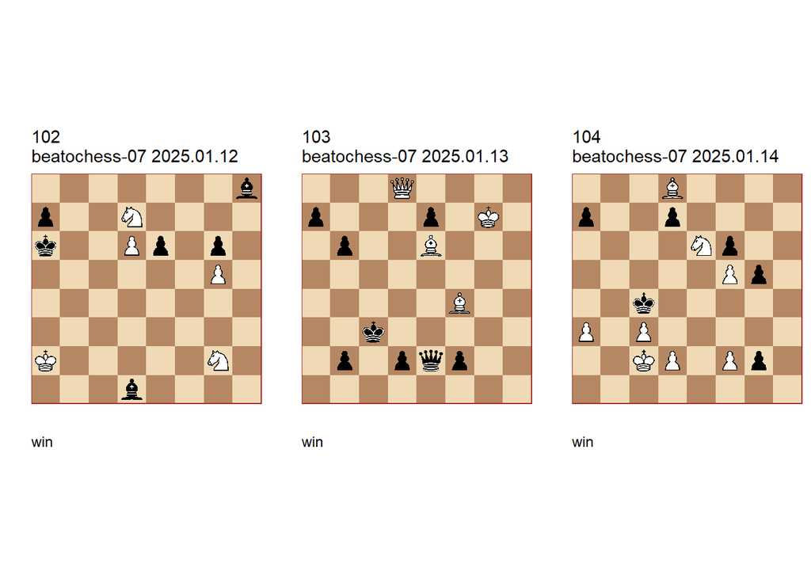

**102** correction of Filaretov 1926 (+0062.22a2a6) U1. **1. Nb8+** (1. Nf6 Kb7 2. Nf4 Kc6 3. Nxg6 Kxd6 4. Nxh8 Ke5) **1… Kb7 2. d7 Kc7 3. Nf4 Bg4 4. Nxg6 Bc3 5. Ne5!** (5. Kb3? Bg7 6. Ne5 Bxe5 7. Nc6 Bd1+) **5… Bxe5 6. Nc6 Kxd7 7. Nxe5+ Ke7 8. Nxg4 1-0**.

**103** correction of Topcheev 1926 (+4020.03e7a3) U2. **1. Qc7+ Kd4** (1… Kb4 2. Qxe7+ Kc3 3. Qc7+ Kb4 4. Bd6+) **2. Be3+! Qxe3** (2… Kxe3 3. Qe5+ Kd3 (3… Kf3 4. Qd5+) 4. Bf5+) **3. Qc4+ Ke5 4. Qd5+ Kf4 5. Qf5+ Kg3 6. Qh3+ Kf4 7. Qg4+ Ke5 8. Qf5+ Kd4** (8… Kd6 9. Qd5+ Kc7 10. Qd7+ Kb8 11. Qc8#) **9. Qd5+ Kc3 10. Qc4# 1-0**.

**104** correction of Kholmakov 1926 (+0011.55c2c4) U2. **1. d3+ Kd5 2. c4+ Ke5 3. Bc7+ d6 4. Nd4!** (4. c5? g1=Q 5. cxd6 Qxf2+ 6. Kb3 Qxf5 7. d7+ Kxe6 8. d8=Q Qb5+ 9. Ka2 Qc6 10. Kb3 Qb5+ 11. Kc2 Qc5+ 12. Kd1 Qg1+ 13. Kd2 Qf2+ 14. Kc3 Qc5+) **4… Kxd4 5. Bb8 g1=Q 6. Bxa7+ Ke5 7. f4+ 1-0**.

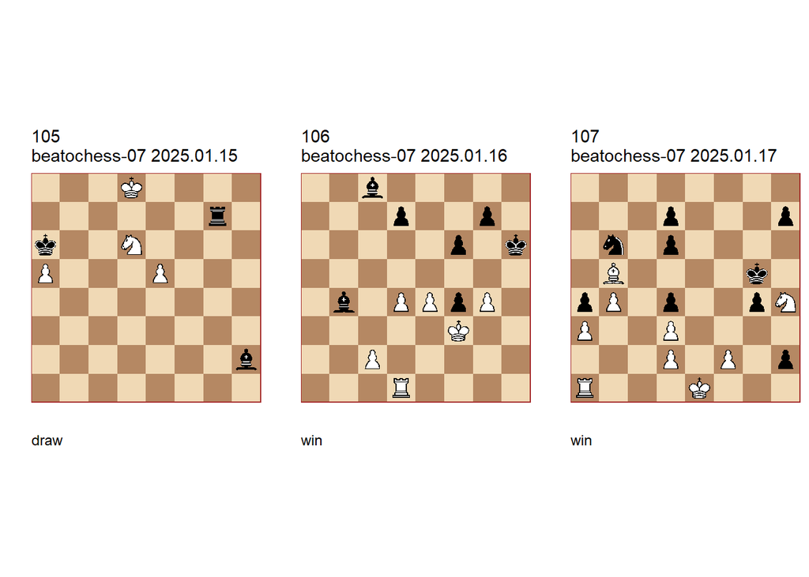

**105** correction of Gulyaev 1926 (=0331.10d8a6) U3. **1. Nf7! Rxf7 2. e6 Bc7+ 3. Kc8 Rh7 4. e7 Rxe7 1/2-1/2**.

**106** correction of Kaminer 1926 (+0160.32f3h5) U2 **1. Rh1+ Kg6** (1… Kg5 2. Rh5+ Kg6 3. Rh8 = **main** ) **2. Rh8 Ba6** (2… Bb7 3. Rb8) **3. Ra8 Bf1** (3… Bc4 4. Ra4) **4. Ra1 Bh3** (4… Bb5 5. Rb1) **5. Rh1 1-0**.

**107** correction of Bondarenko/Kuznetsov 1973 (+0114.47e1g5) U3. **1. Nf3+ gxf3 2. O-O-O Kh4 3. Rh1 Kh3 4. Kd1 Kg2 5. Ke1 d5 6. Ba6 Na8 7. Bc8 Nb6 8. Bb7 h6 9. Ba6 Na8 10. Bc8 Nb6 11. Bb7 h5 12. Ba6 Na8 13. Bc8 Nb6 14. Bb7 h4 15. Ba6 Na8 16. Bc8 Nb6 17. Bb7 h3 18. b5!** (18. Ba6? Na8 19. Bc8 Nc7! 20. Bb7 Nb5 21. Bxd5 Nxa3 22. Bxf3+ Kxf3 23. Rxh2 Nc2+ 24. Kd1 Nxb4 25. Rxh3+ Kxf2 26. Rh7 a3 27. Rxd7 a2 28. Ra7 Kf3) **18… Na8 19. Bxd5** (19. Bxa8? Kxh1 20. Kf1 d6) **1-0**.

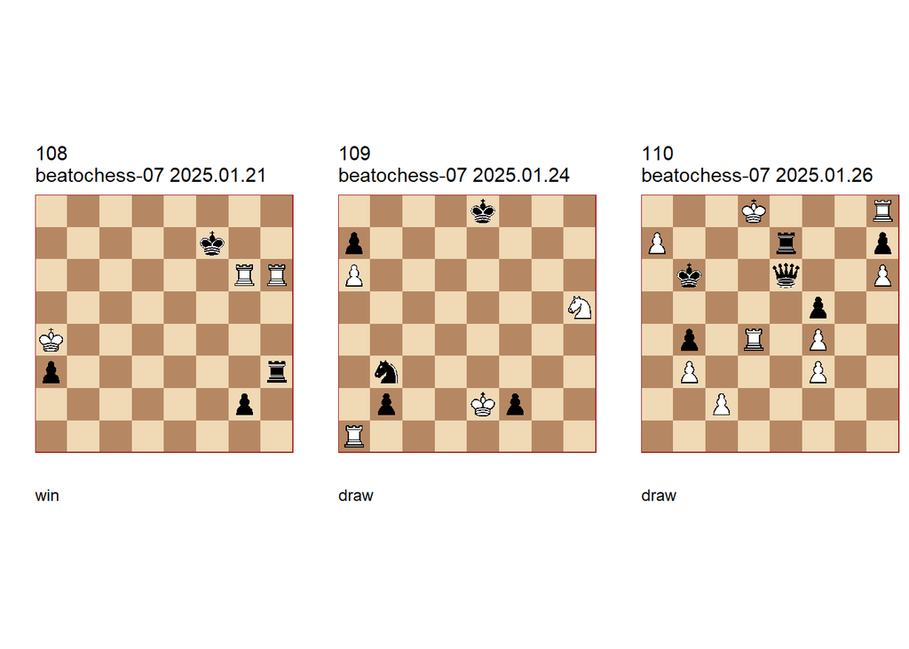

**108** version of Dolgov 1973 (+0500.02b5e7) U2. **1. Rf6+ Ke7 2. Re6+ Kd7 3. Rd6+ Kc7 4. Rc6+ Kb7 5. Rb6+ Kc7** (5… Ka7 6. Ra6+ Kb7 7. Rhb6+ Kc7 8. Rc6+ Kd7 (8… Kb7 9. Rab6+ Ka7 10. Rb1) 9. Rg6) **6. Rhc6+ Kd7 7. Rd6+ Ke7 8. Re6+ Kd7** (8… Kf7 9. Rbc6) **9. Rbd6+ Kc7 10. Rd1 1-0**.

**109** correction of Nadareishvili 1982 (=0104.02e2e7) (v) U2. **1. Ng7+** (1. Nf6+? Kf7) **1… Ke7** (1… Kf7 2. Rb1) **2. Nf5+ Ke6** (2… Kf6 3. Rb1 f1=Q+ 4. Rxf1 Nc1+ 5. Kd2 b1=Q 6. Nd4+ Kg6 7. Rxc1) **3. Rb1** (3. Rd1? Nc1+ 4. Kf1 Kxf5! 5. Rd5+ Ke4 6. Rb5 Nd3) **3… f1=Q+ 4. Rxf1 Nc1+ 5. Kd2 b1=Q 6. Nd4+ Kd5** (6… Ke5 7. Nc6+ Kd6 8. Rxc1) **7. Nc2 Nb3+ 8. Kc3 Nc1 9. Kd2 1/2-1/2**.

**110** correction of Gurgenidze/Mitrofanov 1982 (=3500.43d8b6) U3. **1. a8=Q Rd7+! 2. Rxd7 Qf6+ 3. Re7** (3. Kc8? Qc3+) **3… Qd4+ 4. Qd5!** (4. Ke8? Qxh8+ 5. Kd7 Qxa8) (4. Rd7? Qxh8+ 5. Ke7 Qxa8) **4… Qxd5+ 5. Ke8 Qa8+** (5… Qc6+ 6. Rd7 Qc8+ 7. Rd8 Qe6+ 8. Kf8 Qf6+ 9. Kg8 Qxd8+ 10. Kxh7) **6. Kf7 Qxh8 7. Re6+ Kc7 8. Re7+ Kd8 9. Re5! Kd7 10. Re7+ Kd6 11. Re6+ Kd5 12. Re5+ Kd6 13. Re6+ 1/2-1/2**.

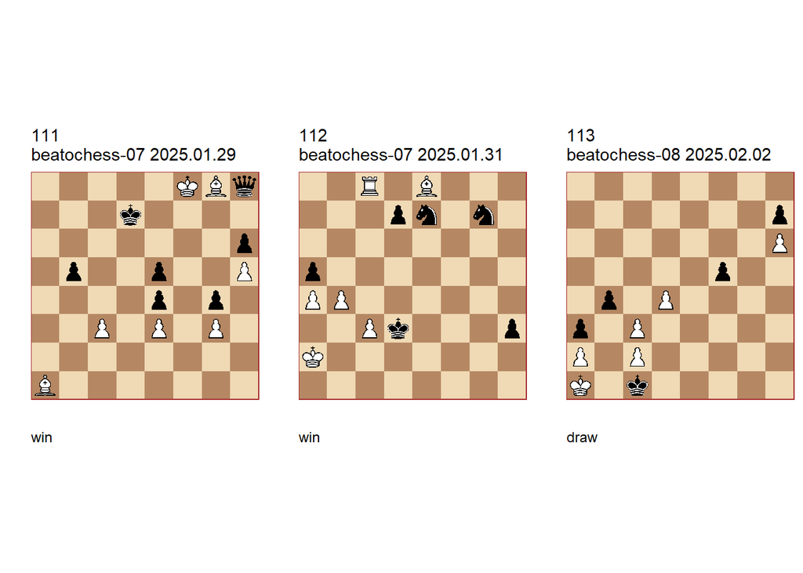

**111** correction of Bordenyuk/ 1981 (+3020.34f8a6) U3. **1. Kf7 Kc6 2. Bb2 b4 3. cxb4 Kb5 4. Ba3!** (4. Bc3? Kc4 5. Be1 Kb5 6. Bd2 Kc4 7. Bc1 Kxb4) **4… Ka4 5. b5! Kxa3 6. b6 Kb2 7. b7 Ka1 8. b8=B!** (8. b8=Q? Qf6+ 9. Kxf6) (8. b8=N Kb2 9. Nd7 Kc3 10. Nf8 Kd3 11. Ng6 Qxg8+ 12. Kxg8 Kxe3) **1-0**.

**112** correction of Sochnev 1976 (+0116.33a2d3) U3. **1. Rd8 h2 2. Bxd7 h1=Q** (2… Nh5 3. Bc6+ Kxc3 4. Bb7 Kxb4 5. Rh8 Nf6 6. Rh4+) **3. Bc6+ Nd5 4. Rxd5+ Kxc3** ( 4… Kc2 5. Rd2+) **5. Rc5+** (5. Rd3+ Kxd3 6. Bxh1 Kc4) **5… Kxb4 6. Rb5+ Kxa4 7. Bd7! Qh3 8. Rf5+ Kb4 9. Rf4+ 1-0**.

**113** version of Amiryan 1981 (=0000.43a1c1) U3. **1. d5 f4 2. d6 f3 3. d7 f2 4. d8=Q f1=Q! 5. Qf6 Qg1 6. Qd4** (6. Qg7? Qh1) **6… Qf1** (6… Qh1 7. Qf2) **7. Qf6 Qe1 8. Qe5 Qd1 9. Qd4** (9. Qh2? Qf1!) **9… Qf1 10. Qf6 Qe1 11. Qe5 1/2-1/2**.

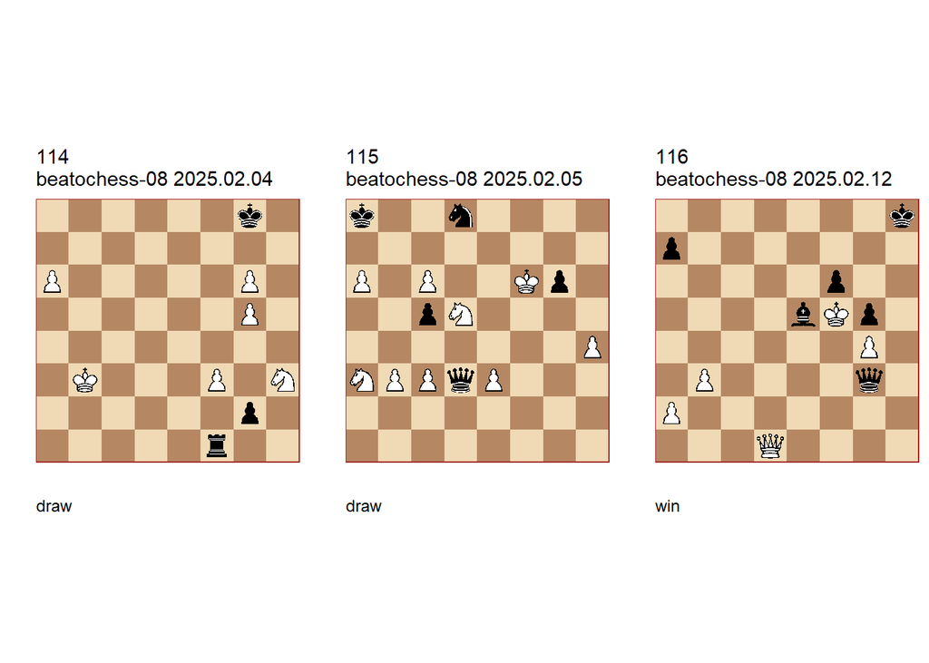

**114** correction of Nestorescu 1983 (=0301.31b2g8) U3. **1. Kb2!** (1. Ka2 Rd1) **1… Rf2+** (1… Rd1 2. a7 Rd8 3. Kc2 Ra8 4. Kd2 Rxa7 5. Ke2) **2. Kb3** (2. Ka3 or ) **2… Rxf3+ 3. Ka4 Rxh3 4. a7 Rh4+** (4… g1=Q **main** 5. a8=Q+ Kg7 6. Qb7+ Kxg6 7. Qb6+ Qxb6) **5. Ka3 g1=Q 6. a8=Q+ Kg7 7. Qb7+ Kxg6 8. Qb1+ Qxb1 1/2-1/2**.

**115** correction of Gogberashvili 1983 (=3015.22f6a8) U3 U2 . **1. Nb5** (1. c7? Qxa6+ 2. Kg7 (2. Ke7 Qe6+ 3. Kxd8 Qxd5+) 2… Ne6+) **1… Nxc6** (1… Qf5+ 2. Ke7 Qe6+ 3. Kxd8 Qxd5+ 4. Kc8 Qe6+ 5. Kc7 Qxe3 6. c4) **2. Ndc7+ Kb8 3. a7+ Nxa7 4. Na6+ Kc8 5. Nxa7+ Kd8 6. Nc6+ Ke8 7. Nc7+ Kf8 8. Ne6+ Kg8 9. Ne7+ Kh7 10. Kf7 Qxc3** (10… Qxe3 11. Nf8+ Kh6 12. Ng8+ Kh5 13. Nxg6 Kg4 14. Nf6+ Kf3 15. Nd5 Qe4 16. c4) **11. Nf8+ Kh6 12. Ng8+ Kh5 13. Nf6+ Kxh4 14. Nxg6+ Kh3 15. Nf4+ Kh2 16. Ng4+ Kh1 17. Nf2+ Kh2 18. Ng4+ Kh1 19. Nf2+ 1/2-1/2**.

**116** correction Sochnev 1982 (+4030.24f5h8) U3 (U2). **1. Kg6 Bd6 2. Qf1 Bf4** (2… f5 3. Qa6 Qc3 4. Qxa7 Qc7 5. Qxc7 Bxc7 6. Kxf5) **3. Qc4 Bc7 4. Qe4 Be5 5. Qd5** ( 5. Qa8+ Bb8 6. Qe4 Be5) **5… Bd6 6. Qf5 Qc3 7. Qe4 Qe5 8. Qa8+ Bb8 9. Qc6 Bc7 10. Kf7** e.g. **10… Kh7 11. Qh1+** (11. Qf3 or ) **11… Qh2 12. Qe4+ Kh8 13. Qe8+ Kh7 1-0**.

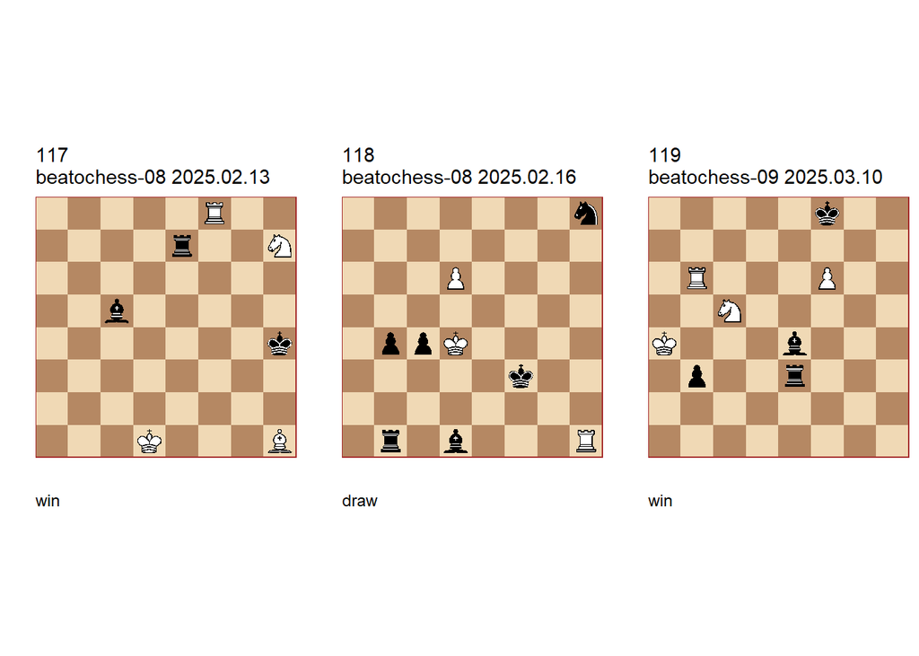

**117** correction of Pogosyants 1983 (+0441.00c1g4) U3. **1. Rh8 Bd4 2. Nf6+ Kg5** (2… Kg3 3. Rg8+! Kh2 4. Nd5! Rg7 5. Rh8+! +-) **3. Ne4+ Rxe4 4. Rg8+ Kf4 5. Rf8+ Ke3** (5… Ke5 6. Re8+) **6. Rf3# 1-0**.

**118** correction of Falk 1985 (=0433.12c4e3) U2. **1. d7 Nf7 2. Rf1+ Kg3 3. Rxf7 Bb3** (3… Be2 **main** 4. Ke3 Rd1 5. Kxe2 Rd6 6. Ke3 (6. Rg7+? Kf4 7. Rh7 Ke5 8. Rh5+ Ke4 9. Rh4+ Kd5 10. Ke3 Rxd7 11. Rd4+ Kc6 12. Rxc4+ Kb5) 6… b3 7. Rf3+) **4. Rg7+ Kf3 5. Rf7+ Ke2 6. Re7+ Kf2 7. Rf7+ Kg3 8. Rg7+ Kf4 9. Rf7+ Kg4 10. Rg7+ Kf5** (10… Kh5 11. Rg5+) **11. Rf7+ Ke6** (11… Kg6? 12. Rf6+) **12. d8=N+ Kd6 13. Nb7+ Kc6 14. Nd8+ Kd6 15. Nb7+ Kc6 16. Nd8+ Kb6 17. Rb7+ 1/2-1/2**.

**119** correction of Nestorescu 1983 (+0431.11b4g8) U2 **1. Nd7+! Kg8** (1… Ke8 **main** 2. Ne5 Bb7 3. Re6+ Kf8 4. Nd7+ (4. Ka3? Bc6 5. Nd7+ Bxd7 6. Rxe3 Bc6 7. Re7 Bd5 =) 4… Kg8 5. Rxe3 Bc6+ 6. Kxb3 Bxd7 7. Re7 Bc6 8. Kc4 Ba4 9. Rb7 ) **2. Rb8+ Kf7 3. Ne5+ Ke6 4. f7 Bc6+ 5. Ka3 b2+ 6. Kxb2 Re2+ 7. Kc3 Rf2 8. Re8+ Kd5 9. Nc4 Rxf7 10. Re5# 1-0**.

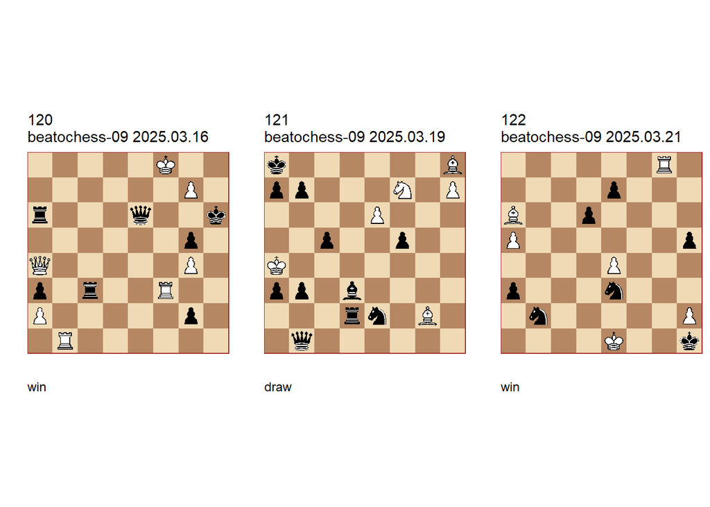

**120** correction of Silaev 1983 (+4800.22f8h6) U2. **1. Rh3+!** (1. g8=N+? Kg6 2. Ne7+ Kh7 3. Rxc3 Qh6+!) **1… Rxh3** (1… Kg6 2. Qe4+ Qxe4 3. g8=Q+ Kf6 4. Qg7+ Ke6 5. Qe7+ Kd5 6. Rd1+) **2. g8=N+!** (2. g8=Q? Rf3+) **2… Qxg8+** (2… Kg6 3. Qc2+) (2… Kh7 3. Rb7+ Kh8 4. Qd4+) **3. Kxg8 Rg6+** (3… Rxa4 4. Rb6#) **4. Kh8!** (4. Kf7? Rf3+ 5. Ke7 (5. Ke8 Re6+ (5… Rg8+? 6. Ke7 Rg7+ (6… Rf1 7. Rb6+) 7. Ke6 Rf1 8. Qe8 Rc7 (8… Rg6+ 9. Ke5 Kh7 10. Qd7+ Rg7 11. Qd3+) 9. Qh5+ Kg7 10. Qxg5+) (5… Rf1? 6. Qb3 Rxb1 (6… g1=Q 7. Qh3+ Kg7 8. Rb7+ Kf6 9. Qc3+ Ke6 10. Qc4+ Kd6 11. Rd7+ Ke5 12. Rd5+ Kf6 13. Qc3+) 7. Qxb1 Rc6 8. Qg1 Rc2 9. Kf8) 6. Kd7 Rf1 7. Qa8 g1=Q 8. Qh8+ Kg6 9. Qg8+ Kh6 10. Qxe6+ Kg7 11. Qe5+ Kh7 12. Rxf1 Qxf1 13. Qf5+ Qxf5+ 14. gxf5 g4 15. f6 g3 16. f7 g2 17. f8=Q g1=Q) 5… Rf1 6. Qe8 Kh7) **4… Rf6** (4… Re6 5. Qe4) (4… Rd3 5. Qe8) **5. Qe8!** (5. Qb4? g1=Q 6. Rxg1 Kg6+ 7. Kg8 Rh8+ 8. Kxh8 Rf8+ 9. Qxf8) (5. Rb6? 5… Rxb6 6. Qa7 Kg6+ 7. Kg8 Rb8+ 8. Qxb8 Rh8+ 9. Kxh8 g1=Q) **5… g1=Q 6. Rb7 Rf8+ 7. Qxf8+ Kg6+ 8. Kg8 Rh8+ 9. Kxh8 Qh1+ 10. Qh6+!** (10. Kg8? Qh8+ 11. Kxh8) **10… Qxh6+ 11. Kg8! Kf6 12. Rb6+ 1-0**.

**121** correction of Kozdon1983 (=3357.25a4a8) U3. **1. Bc3!** (1. Be5? Bb5+ 2. Ka5 (2. Kxb5 Qd3+) 2… Qe1 3. h8=Q+ Rd8+) (1. Bd4? Nc3+! 2. Bxc3 (2. Ka5 Qh1 3. Bxh1 Rh2 4. e7 Bb5) 2… Bb5+ 3. Ka5) **1… Qh1** (1… Nxc3+ leads to the **main** line ) (1… a6 2. h8=Q+ Ka7 3. Bxb7 Nxc3+ 4. Ka5 Kxb7 5. Qg7) **2. Bxh1 Nxc3+ 3. Ka5 Rh2 4. e7 Bb5 5. Nh6! Rxh6 6. Bc6! Bxc6 7. h8=Q+ Rxh8 8. e8=Q+ Rxe8 1/2-1/2**.

**122** correction of Pervakov 1985 (+0116.23e1h1) U3. **1. Rc8 a2 2. Rc1 a1=Q 3. Rxa1 Nc2+ 4. Kf2+ Nxa1 5. Bb5 Nd1+ 6. Kg3 Nc3 7. Bc6 Ne2+ 8. Kh4** (8. Kf2? Nf4 9. a6 Ne6) **8… Nd4 9. Bd7 Nf3+ 10. Kg3** (10. Kxh5? Nb3 11. a6 Nc5 12. a7 Nxd7 13. a8=Q Kxh2) (10. Kh3? Ne5 11. Bb5 Nf3 12. a6 Ng5+) **10… Ne5** (10… Nd2 11. a6 Nc4 12. Be6 Nb6 13. h4) **11. Bb5 Nb3 12. a6 Nd4 13. a7** (13. Be8? h4+ 14. Kxh4 Nc4 15. Kg3 Ne2+ 16. Kf2 Nc3) **13… Nxb5 14. a8=Q 1-0**.

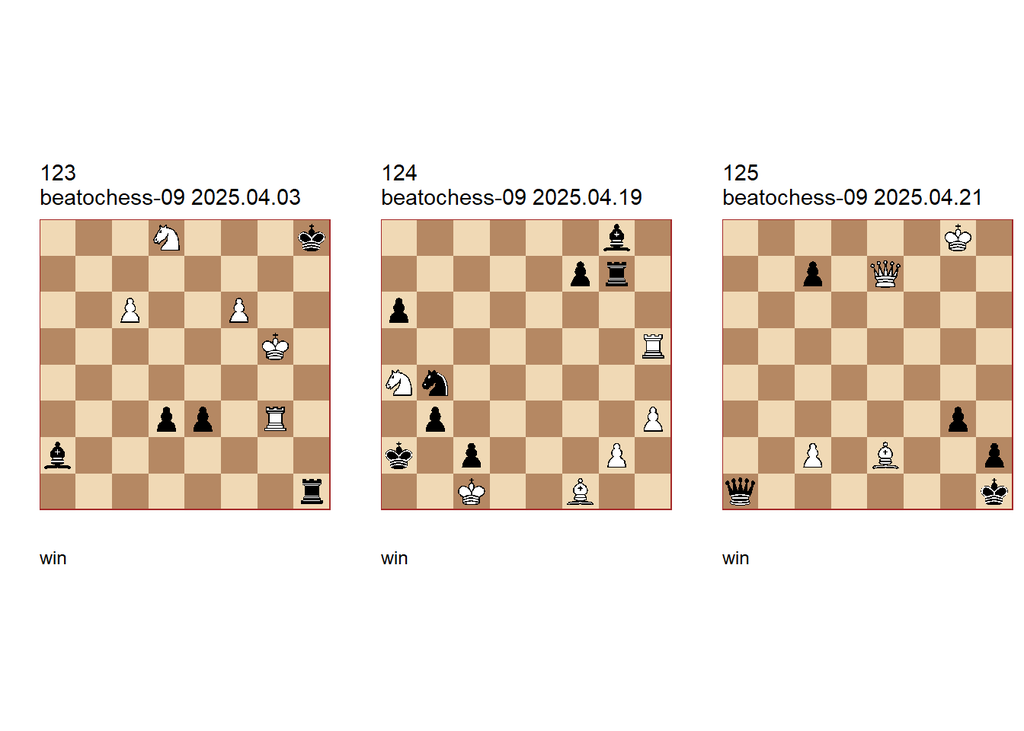

**123** correction of Maksimovkikh/Shupletsov 1984 (+0431.22g5h8) U1 **1. Rh3+!** (1. c7? Rc1 2. Kg6 d2 3. f7 Bxf7+ 4. Nxf7+ Kg8) **1… Rxh3 2. c7 Rh5+! 3. Kxh5 d2 4. Nf7+! Bxf7+ 5. Kh6! d1=Q 6. c8=Q+ Bg8 7. Qb7! Bf7 8. Qa8+! Bg8 9. Qg2! Qd7 10. Qg7+! Qxg7+ 11. fxg7# 1-0**.

**124** correction of Bondarenko/Kakovin 1981 (+0444.34c1a1) (U2). **1. Nc3+** (1. Ra5? b2+ 2. Nxb2+ Kb3 3. Bc4+ Kc3) **1… Ka1 2. Ra5+ Na2+ 3. Rxa2+ bxa2 4. Ne2 Bh7** ( 4… f5 **main** 5. Nd4 Rc7 6. Bc4! Bxc4 (6… Rxc4 **main** 7. Nb3#) 7. Nxc2#) **5. Nd4 Rg3 6. Bd3! Bxd3** (6… Rxd3 **main** 7. Nxc2#) **7. Nb3# 1-0**.

**125** correction of Amiryan 1983 (+0010.24f6h1) (v) U2. **1. Bf3+ g2 2. Qe2 Qg1** (2… Qa2+ 3. Kg7 Qa1+ 4. Kg6) **3. Kf7! c5 4. Ke6! c4 5. Kd5! c3 6. Ke4! Qf2 7. Qd1+ Qg1 8. Bxg2+! Kxg2 9. Qf3# 1-0**.

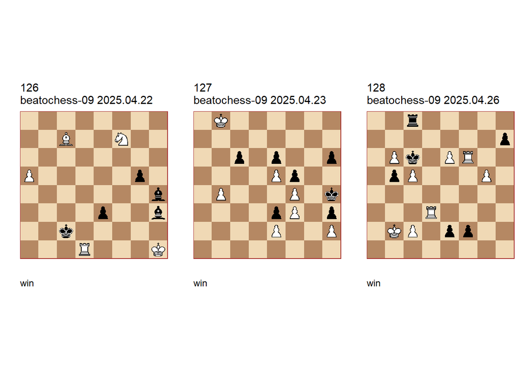

**126** correction of Fritz 1984 (+0171.11h1c2) U2. **1. a6 e2 2. Rd2+ Kxd2 3. Ba5+ Ke3 4. a7 Bg4 5. Ne5 Bf5 6. Nc4+ Kd4 7. Nd6 Be6 8. Nb5+ Kc5 9. Nc7 Bd7** (9… e1=Q+ 10. Bxe1 Bd7 11. Bb4+ Kb6 12. a8=Q Bc6+ 13. Nd5+) **10. Na6+ Kb5 11. Nb8 1-0**.

**127** correction of Balanovsky 1986 (+0000.55b8h4) TT U3. **1. Ka8!** (1. Ka7? Kh5 2. Ka6 Kh4 3. Ka5 Kh5 4. Ka4 Kh4 5. Kb3 (5. Ka3 c5 6. b5 c4 7. b6 c3 8. b7 c2 9. Kb2 h5 10. b8=Q c1=Q+ 11. Kxc1) 5… c5 6. b5 c4+) **1… Kh5? 2. Ka7 Kh4** ( 2… Kg6 3. Ka6 c5 4. b5 c4 5. b6 c3 6. b7 c2 7. b8=Q c1=Q 8. Qg8+ Kh5 9. Qxe6) **3. Ka6 Kh5 4. Ka5 Kh4 5. Ka4 Kh5 6. Kb3 Kh4** (6… c5 7. b5 c4+ 8. Kc3 Kh4 9. b6 h5 10. Kd4 c3 11. b7 c2 12. b8=Q c1=Q 13. Qd8#) **7. Kc3** (7. Kc2 or ) **7… h5 8. Kd3** (8. Kd4 or ) **8… c5 9. Kxe3 c4 10. Kd2 c3+ 11. Kc1 c2 12. e4 1-0**.

**128** version of Yarmonov 1986 (+0500.25b2d8) U1. **1. e7+** (1. Rd8? e1=Q 2. Rxc8+ Kd5 3. Rf5+ (3. Rd8+ Kxc5) ) **1… Kb7 2. e8=Q** (2. Rd7+? Kb8 3. b7 e1=Q 4. bxc8=Q+ Kxc8 5. Rd8+ Kc7 6. e8=Q Qb4+ 7. Kc1 Qe1+) **2… Rxe8 3. Rf7+! Kb8 4. c6 f1=Q** (4… e1=Q 5. Rd8+! Rxd8 6. c7+ Kc8 7. b7+ Kxb7 8. cxd8=Q+) **5. Re7** ( 5. Rdd7? Qb1+) **5… Qf8** (5… e1=Q 6. Rd8+! Rxd8 7. c7+ Kc8 8. b7+ Kxb7 9. cxd8=Q+ Qxe7 10. Qxe7+ Kc6 11. Qxh7) **6. Rd8+! Rxd8 7. c7+ Ka8 8. b7+ Ka7 9. b8=Q+ Rxb8 10. c8=N+! Ka6** (10… Ka8 **main** 11. Ra7#) **11. Ra7# 1-0**.

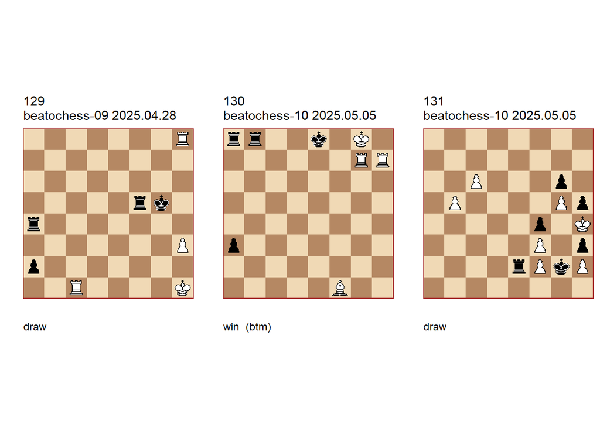

**129** correction of Kalandadze 1984 (=0800.11h1f6) U2. **1. Rg1+** (1. Rg8+? Kh4 2. Rh8+ Kg3 3. Ra1 Rb5) **1… Kf6 2. Rf8+ Ke6 3. Re1+ Re5 4. Re8+ Kd6 5. Rd1+ Rd5 6. Rd8+ Kc6 7. Rc1+ Rc5 8. Rc8+ Kb6 9. R8xc5 a1=Q 10. Rc6+** (10. Rc8 Qe5 11. Rb1+ Ka7) **10… Kb5 11. Rc8 Qe5 12. Rb1+ Rb4 13. Rxb4+ Kxb4 14. Rg8 1/2-1/2**.

**130** correction of Banaszek 1985 (+0810.00g8e8) U2. **1… Rb7! 2. Bb5+!** (2. Rh8? O-O-O+!) (2. Rxb7? O-O-O+!) **2… Rxb5 3. Re7+!** (3. Rh8? O-O-O+) **3… Kd8 4. Kf7 Rf5+ 5. Ke6 Rf8 6. Rd7+ Kc8 7. Rc7+ Kb8 8. Rb7+ Kc8 9. Rhc7+ Kd8 10. Rd7+ Ke8** (10… Kc8 11. Ke7) **11. Ra7! Rb8 12. Rdb7! Rc8 13. Re7+ Kd8 14. Rad7# 1-0**.

**131** correction of Kolesnikov 1985 (=0300.64h4g2) U3. **1. c7 Rc2** (1… Re8 2. b6 Kxh2 3. b7 Kg2 4. c8=Q Rxc8 5. bxc8=Q h2 6. Qh3+ Kg1 7. Qxh2+ Kxh2) **2. b6 Kxh2 3. b7** (3. c8=Q? Rxc8 4. b7 Rf8 5. b8=Q Rf5) **3… Kg1** (3… Rxc7 4. b8=Q Kg2 5. Qc8! h2 6. Qh3+ Kg1 7. Qxh2+ Kxh2) **4. c8=Q** (4. Kxh3? Rxf2) **4… Rxc8 5. bxc8=B** (5. bxc8=Q? h2) **5… h2 6. Bh3! Kxf2** (6… h1=Q) **7. Bg2 Kg1 8. Bh3 h1=B! 9. Bg2! Kh2** (9… Bxg2) (9… Kxg2) **10. Bh3** (10. Bf1 or ) **10… Bxf3 11. Bg2 Bd1** (11… Be2 12. Bf3 Bf1 13. Be4 (13. Bg2? Kg1) 13… Kg1 14. Bxg6 f3 15. Bf7 f2 16. g6 Bd3 17. g7) **12. Bf3 Bc2** (12… Bxf3) **13. Be4 Bd1 14. Bf3** (14. Bxg6? f3 15. Be4 f2 16. Bd3 Bc2 17. Bc4 Bg6) **1/2-1/2**.

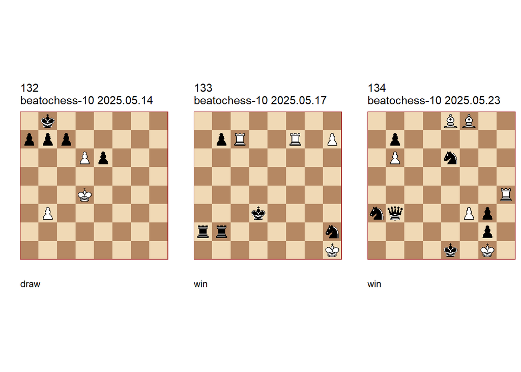

**132** correction of Katsnelson & Maksimovskikh 1987 (=0000.24d4b8) U2. **1. d7 c5+ 2. Ke5 Kc7 3. Kxe6 Kd8 4. Kd6** (4. Kd5? Kxd7 5. Kxc5 Ke6) **4… c4 5. bxc4 a5 6. Kc5 Kxd7 7. Kb6** (7. Kb5? Kd6 8. Ka4 Kc6 9. Kxa5 Kc5) **7… Kd6 8. Kb5! Ke5 9. Kxa5 1/2-1/2**.

**133** correction of Dobrescu 1986 (+0800.12h1e3) U2. **1. Rfd7+** (1. Rc3+? Ke4!) **1… Ke3** (1… Ke4 2. Rd4+!) **2. Rc3+ Ke4 3. Rd4+ Kf5 4. Rc5+ Ke6 5. Re5+ Kf7 6. Rd7+ Kg6 7. Re6+ Kf5 8. Rf6+ Ke4** (8… Ke5 9. h8=Q Rb1+ 10. Rf1+) **9. Re7+ Kd5 10. Re5+ Kc4 11. Rf4+ Kd3 12. Rd4+ Kc3 13. h8=Q Rb1+ 14. Rd1 Rxd1+ 15. Re1+ Kd2 16. Qxh2+ Kxe1 17. Qxa2 1-0**.

**134** correction of Shansin 1987 (+3126.12g1e1) U2. **1. Re4+ Kd2 2. Bh6+ Ng5! 3. Bxg5+ Kd1 4. Ba4** (4. Rd4+ Ke2 5. Re4+ Kd1) **4… Nc2! 5. Re1+! Kxe1 6. Bxb3 Nd4 7. Bd5 Nxf3+ 8. Kxg2 Nxg5 9. Kxg3 Kd2 10. Kf4 Kc3 11. Ke5 Kb4 12. Kd6 Kb5 13. Kc7 Kc5 14. Kxb7 Kxd5 15. Ka8! 1-0**.

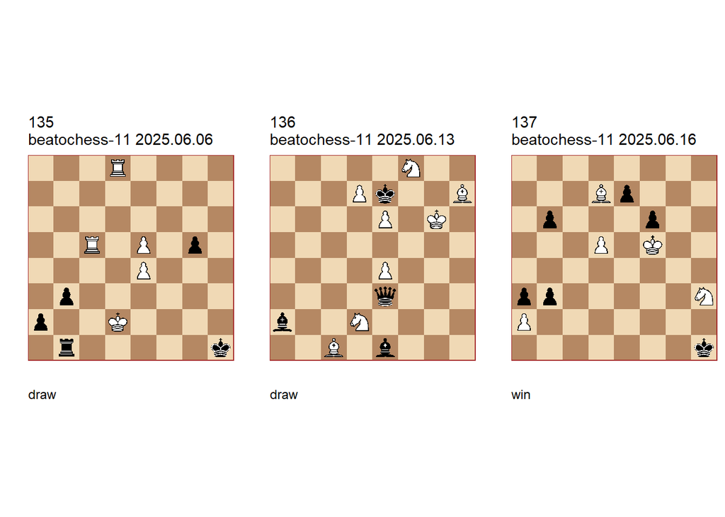

**135** correction of Gurgenidze & Katsnelson 1987 (=0500.23d2h1) U2 . **1. Ra5 b2 2. Rxa2 Rd1+ 3. Ke2 Re1+ 4. Kf2 Rf1+ 5. Kg3 Rg1+ 6. Kf3 g4+ 7. Kf4 Rf1+ 8. Kg5 b1=Q 9. Rh8+ Kg1 10. Rhh2 Qc1+ 11. Kh5** (11. Kg6 or 11… Qc6+ 12. Kg5) **1/2-1/2**.

**136** correction of Lewandowski 1986 (=3082.31g6e7) U3. **1. Nb3 Qxe4+ 2. Kg7 Bc3+** ( 2… Qe5+ 3. Kg8 Qf6 4. Ba3+) **3. Kg8 Qg4+ 4. Ng6+ Kd8 5. Bg5+ Qxg5 6. e7+ Kxd7 7. e8=Q+ Kxe8 1/2-1/2**.

**137** correction of Kivi 1965 (+0011.24f5h1) U2. **1. d6 exd6 2. Kg4 Kh2 3. Be6 f5+ 4. Kh4 d5 5. Bxd5 b2 6. Ng5 b1=Q 7. Nf3+ Kg2 8. Nd2+ 1-0**.

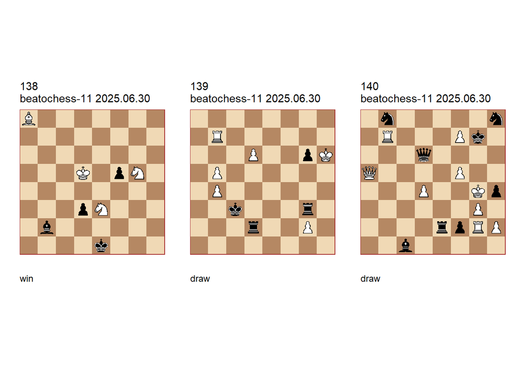

**138** correction of Kozirev 1986 (+0042.02d5e1) U1. **1. Kc4 Bc1!** (1… d2 2. Bf3 Bf6 3. Nh3) **2. Nf3+** (2. Kxd3? Kf2 3. Nd1+ Ke1 4. Ne3 Kf2 5. Nh3+ Kg3 6. Ng1 Kf2 7. Nh3+ Kg3 8. Ng5 Kf2) **2… Ke2 3. Nxf5! d2 4. N3d4+ Ke1 5. Nc2+ Kf2! 6. Nfe3 Ke2 7. Kc3 d1=Q 8. Nxd1 Bd2+** (8… Kxd1 9. Bf3#) **9. Kb2 Kxd1 10. Bf3# 1-0**.

**139** correction of Rumyantsev 1986 (=0700.31h6c3) U1. **1. Rc7+** (1. d7? Kxb4) **1… Kxb4 2. b6 Rxd6 3. b7 Rb6** (3… g5+ **main** 4. Kh5 Rb6 5. Rc6 Rb5 6. b8=Q Rxb8 7. Rb6+ Rxb6) **4. b8=Q Rxb8 5. Rb7+ Rxb7 1/2-1/2**.

**140** correction of Dobrescu & Nestorescu 1986 (=4536.41g4g7) (c) U2. **1. f6+ Qxf6** ( 1… Kf8 2. Rxf2) **2. f8=Q+ Kxf8 3. Rxf2 Rxf2 4. Qc5+ Kg8 5. Qc8+ Qf8 6. Rxb8 Kg7 7. Qc7+ Qf7** (7… Rf7 8. Qe5+) **8. Rb7 Kg6** (8… Qxc7 9. Rxc7+ Nf7 10. Rxc1) **9. Qc6+ Qf6 10. Rb6 Kg7 11. Qc7+ Qf7 12. Rb7 Kg8 13. Qc8+ 1/2-1/2**.

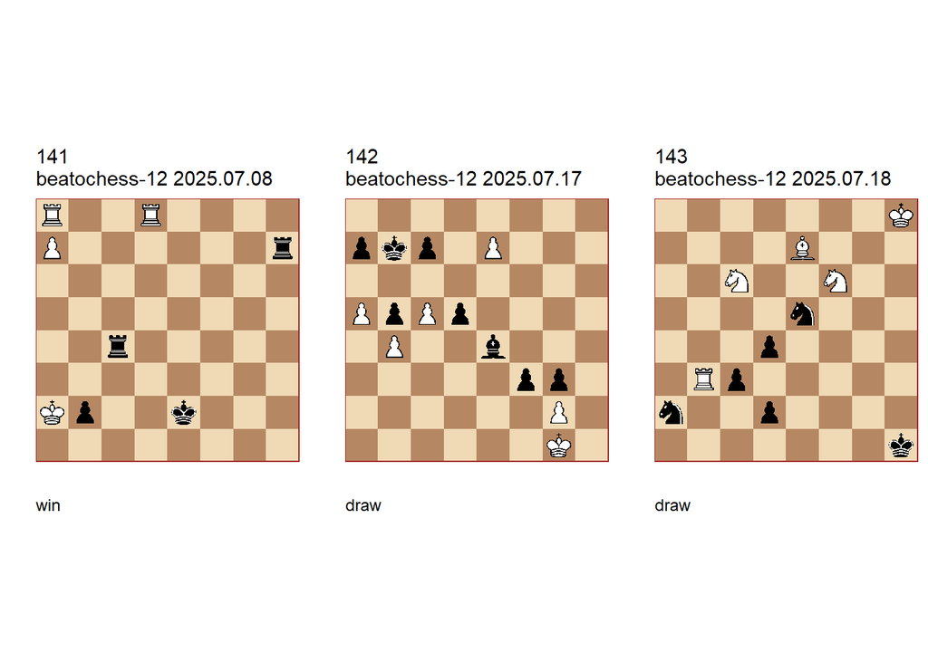

**141** correction of Gurgenidze 1988 (+0800.11a2e3) U3. **1. Re8+ Kf2 2. Re2+!** (2. Rf8+? Kg2 3. Rf2+ Kh3) **2… Kxe2 3. Re8+ Kd1! 4. a8=Q b1=Q+ 5. Kxb1 Rb7+! 6. Ka2!** (6. Qxb7? Rb4+ 7. Qxb4) **6… Rc2+ 7. Ka3 Rc3+ 8. Ka4 Rcc7! 9. Rd8+!** (9. Qd8+? Rd7 10. Qc8 Rbc7!) **9… Kc2 10. Rc8! 1-0**.

**142** correction of Ossadnik 1977 (=0030.56g1b7) U3. **1. c6+ Ka6 2. e8=R!** (2. e8=Q? f2+ 3. Kf1 Bd3+ 4. Qe2 Bc4) **2… f2+ 3. Kf1 Bd3+ 4. Re2 Bxe2+ 5. Kxe2 d4 6. Kf1 d3 1/2-1/2**.

**143** correcction of Nadareishvili 1987 (=0118.03h8h1) U1. **1. Ne4!** (1. Rb1+? Nc1 2. Ne4 (2. Nxe5 c2 (2… d1=Q 3. Ba3) ) 2… Nd3) **1… d1=Q!** (1… c2 2. Nxd2 c1=Q 3. Rb1) **2. Nf2+ Kg1!** (2… Kg2 3. Nxd1 c2 4. Rb2) **3. Nxd1 c2 4. Nc3! Nxc3** (4… dxc3 5. Nd4! Ng6+ 6. Kh7 Nxe7 7. Nxc2) **5. Bg5!** (5. Rxc3? dxc3 6. Nd4 Ng6+ (6… c1=Q 7. Ne2+ Kf2 (7… Kf1 8. Nxc1 Ng6+ 9. Kg7 Nxe7 10. Kf6 Nc6 11. Ke6 Ke1 12. Kd5 Na7 13. Kc4 c2 14. Kb3) 8. Nxc1 Ng6+ 9. Kg7 Nxe7 10. Na2 c2 11. Nb4) 7. Kg7 c1=Q 8. Ne2+ Kf1 9. Nxc1 Nxe7 10. Kf6 Nc6 11. Ke6 c2 12. Kd5 Na7 13. Kc4 Ke1 14. Kd3 (14. Kb3 Kd2 15. Kb2 Nb5 16. Nb3+ Kd1 17. Nc1 Nc3 18. Nb3 (18. Nd3 Kd2) 18… Ne2) 14… Kd1 15. Na2 Nc6 16. Kc3 (16. Nc3+ Kc1) 16… Ne7 17. Kd3 Nd5 18. Kc4 Nf4 19. Kc3 Ne2+ 20. Kb2 Kd2) **5… Nf7+ 6. Kg8! Nxg5 7. Nxd4 c1=Q 8. Rxc3! Qd2** (8… Qxc3 9. Ne2+) (8… Qf1 9. Rc1 Qxc1 10. Ne2+) **9. Rc1+! Kf2** (9… Qxc1 10. Ne2+) **10. Rc2 1/2-1/2**.

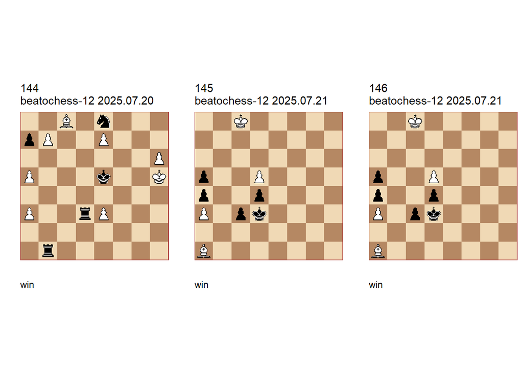

**144** correction of Costeff 1981 (+0613.51h5e5) U3. **1. h7** (1. Kg5? Rdd1 2. Bh3 Rg1+ 3. Bg4 Rh1) **1… Rh1+ 2. Bh3!** (2. Kg4? Rb3) **2… Rxh3+ 3. Kg4 Rxh7 4. b8=Q+ Ke6** (4… Rd6 5. Qb5+ Ke6 6. Qf5+ Kxe7 7. Qxh7+ Kd8 8. Qxa7) (4… Kf6 5. Qf4+ Kxe7 6. Qe4+ Kd8 7. Qxd3+ Rd7 8. Qb5) **5. Qxe8 Rg7+ 6. Kf4!** (6. Kf3? Rd6) **6… Rf7+** (6… Rd6 7. Qf8 Rf7+ 8. Ke4 Rxe7 9. Qf5#) (6… Rd7 7. Qg6+ Rxg6 8. e8=Q+) (6… Rc3 7. Qg6+ Rxg6 8. e8=Q+ Kf6 9. Qe5+) **7. Ke4 Rd7 8. a6!** (8. a4? a6) **8… Rf6** (8… Rd6 **main** 9. Qf8 Rxe7 10. Qf5#) (8… Rdxe7 **main** 9. Qc6#) (8… Rfxe7 **main** 9. Qg6#) (8… Rg7 **main** 9. Qg6+!) (8… Rc7 **main** 9. Qc6+!) **9. Qd8 Rxe7 10. Qd5# 1-0**.

**145** correction of Nestorescu 1987 (+0010.24c8d3) U2. **1. d6 Kc2 2. d7 Kb1 3. d8=Q c2 4. Qxd4 c1=Q+ 5. Bc3 Qxa3** (5… Ka2 **main** 6. Qc4+ Kxa3 7. Bb4+ Kb2 8. Ba3+) **6. Qd3+ Kc1 7. Bd2+ Kb2 8. Bc1+ 1-0**.

**146** correction of Nestorescu 1987 (+0010.24c8d3) U2. **1. d6 Kc2 2. d7 Kb1 3. d8=Q c2 4. Qxd4 c1=Q+ 5. Bc3 Qxa3** (5… Ka2 **main** 6. Qc4+ Kxa3 7. Bb4+ Kb2 8. Ba3+) **6. Qd3+ Kc1 7. Bd2+ Kb2 8. Bc1+ 1-0**.